# 2-1[실습해설].seaborn_chart_기본(tips data)

#### matplotlib 다중 barh 차트

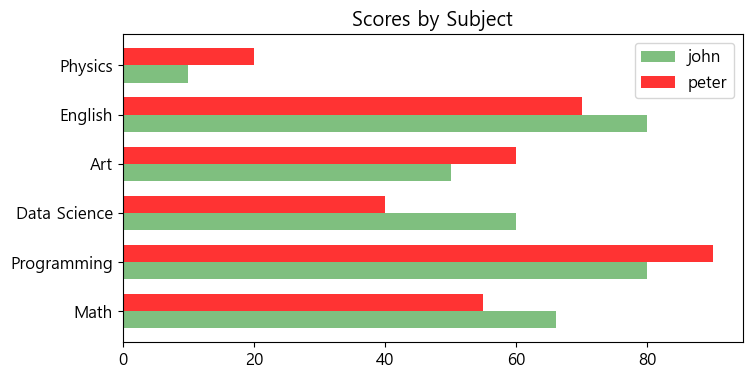

```python
subject = ['Math', 'Programming', 'Data Science', 'Art', 'English', 'Physics']
score1 = [66, 80, 60, 50, 80, 10]
score2 = [55, 90, 40, 60, 70, 20]

# subject 갯수 만큼 숫자리스트 생성(0~5)
sj_num = np.arange(len(subject))

# 넓이 지정
width = 0.35

# subplots 생성
fig, axes = plt.subplots()

# 넓이 설정
axes.barh(sj_num - width/2, score1, width, align='center', alpha=0.5, color='green')
axes.barh(sj_num + width/2, score2, width, align='center', alpha=0.8, color='red')

# ytick 설정
axes.set_yticks(sj_num)
axes.set_yticklabels(subject)

plt.title('Scores by Subject')
plt.legend(['john', 'peter'])

plt.show()
```

#### Seaborn에서 barplot 비교 차트 그리기

- 카테고리 값에 따른 실수 값의 평균과 편차를 표시함
- 편차 표시 : error bar로 표시

**실전 tip.**

- 그래프를 임의로 그려야 하는 경우 -> `matplotlib`
- DataFrame을 가지고 그리는 경우 -> `seaborn`

seaborn 에서는 `hue` 옵션으로 매우 쉽게 비교 **barplot**을 그릴 수 있음

#### tips 데이터 활용

```python
import seaborn as sns
import pandas as pd

file_path = "datas/sns_tips.csv"
tips = pd.read_csv(file_path)
```

```python
tips.head()
```

|  | total_bill | tip | gender | smoker | day | time | size |
| --- | --- | --- | --- | --- | --- | --- | --- |
| 0 | 16.99 | 1.01 | Female | No | Sun | Dinner | 2 |
| 1 | 10.34 | 1.66 | Male | No | Sun | Dinner | 3 |
| 2 | 21.01 | 3.50 | Male | No | Sun | Dinner | 3 |
| 3 | 23.68 | 3.31 | Male | No | Sun | Dinner | 2 |
| 4 | 24.59 | 3.61 | Female | No | Sun | Dinner | 4 |

[tip] : error line 또는 error bar

- 막대의 편차를 표시한 것
- 설정 : default 3  
  sns.barplot(data=tips, x='gender', y='tip', hue='smoker', palette="muted", errwidth=2)
- 없애고 싶으면  
  sns.barplot(data=tips, x='gender', y='tip', hue='smoker', palette="muted", errwidth=0)

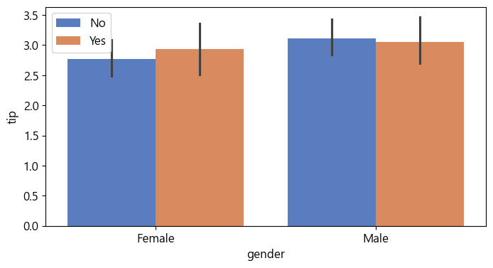

```python
# 성별로 담배를 피는 사람과 안피는 사람별로 tip의 평균 비교

sns.barplot(data=tips, x='gender', y='tip', hue='smoker', palette="muted")
# sns.barplot(data=tips, x='gender', y='tip', hue='smoker', palette="muted", errwidth=3)
# sns.barplot(data=tips, x='gender', y='tip', hue='smoker', palette="muted", errwidth=1)
# sns.barplot(data=tips, x='gender', y='tip', hue='smoker', palette="muted", errwidth=0)
plt.legend(loc="best")
plt.show()
```

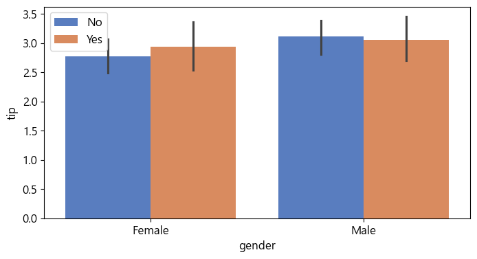

```python
sns.barplot(data=tips, x='gender', y='tip', hue='smoker', palette="muted")
plt.legend(loc="best")
plt.show()
```

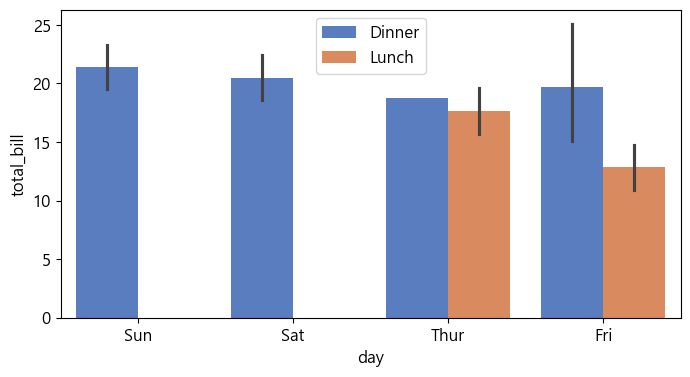

```python
sns.barplot(data=tips, x='day', y='total_bill', hue='time', palette="muted")
plt.legend(loc="best")
plt.show()
```

#### titanic 데이터 활용

```python
titanic = sns.load_dataset('titanic')
titanic.head()
```

|  | survived | pclass | sex | age | sibsp | parch | fare | embarked | class | who | adult_male | deck | embark_town | alive | alone |
| --- | --- | --- | --- | --- | --- | --- | --- | --- | --- | --- | --- | --- | --- | --- | --- |
| 0 | 0 | 3 | male | 22.0 | 1 | 0 | 7.2500 | S | Third | man | True | NaN | Southampton | no | False |
| 1 | 1 | 1 | female | 38.0 | 1 | 0 | 71.2833 | C | First | woman | False | C | Cherbourg | yes | False |
| 2 | 1 | 3 | female | 26.0 | 0 | 0 | 7.9250 | S | Third | woman | False | NaN | Southampton | yes | True |
| 3 | 1 | 1 | female | 35.0 | 1 | 0 | 53.1000 | S | First | woman | False | C | Southampton | yes | False |
| 4 | 0 | 3 | male | 35.0 | 0 | 0 | 8.0500 | S | Third | man | True | NaN | Southampton | no | True |

```python
print(titanic.columns)
```

```
Index(['survived', 'pclass', 'sex', 'age', 'sibsp', 'parch', 'fare',
       'embarked', 'class', 'who', 'adult_male', 'deck', 'embark_town',
       'alive', 'alone'],
      dtype='object')
```

```python
print(titanic.dtypes)
```

```
survived          int64
pclass            int64
sex              object
age             float64
sibsp             int64
parch             int64
fare            float64
embarked         object
class          category
who              object
adult_male         bool
deck           category
embark_town      object
alive            object
alone              bool
dtype: object
```

```python
# pclass를 str로 변환, hue값을 문자형으로 변경
titanic['pclass'] = titanic['pclass'].astype(str)
```

```python
print(titanic.dtypes)
```

```
survived          int64
pclass           object
sex              object
age             float64
sibsp             int64
parch             int64
fare            float64
embarked         object
class          category
who              object
adult_male         bool
deck           category
embark_town      object
alive            object
alone              bool
dtype: object
```

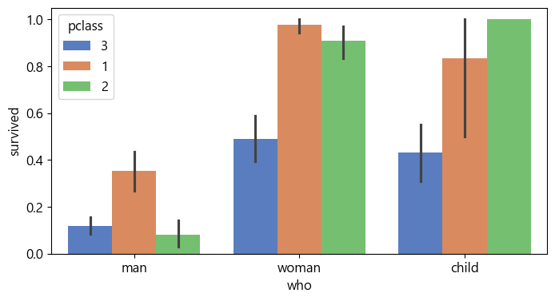

```python
sns.barplot(x='who', y='survived', hue='pclass', data=titanic, palette="muted")
plt.show()
```

## 3. Line Plot

### 3-1. 기본 lineplot 그리기

#### tips 데이터 활용

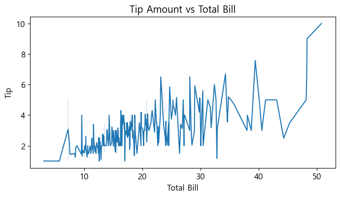

```python
# 라인 플롯 그리기
sns.lineplot(data=tips, x='total_bill', y='tip')
plt.xlabel('Total Bill')
plt.ylabel('Tip')
plt.title('Tip Amount vs Total Bill')
plt.show()
```

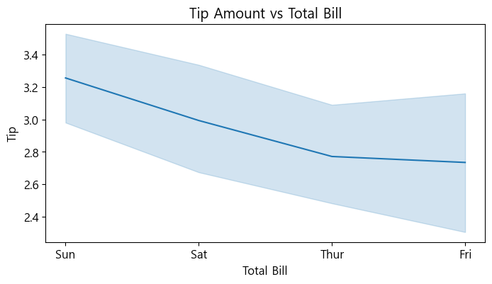

```python
# 라인 플롯 그리기
sns.lineplot(data=tips, x='day', y='tip')
plt.xlabel('Total Bill')
plt.ylabel('Tip')
plt.title('Tip Amount vs Total Bill')
plt.show()
```

- 진한 실선 : 평균
- 음영 표시 부분(ci) : 신뢰 구간(confidence interval)의 표시 여부를 조절하는 역할
  - ci를 명시하지 않으면 : 95% 신뢰구간을 표시함
  - ci= None : 신뢰 구간을 표시하지 않음
  - ci= "sd": 표준 편차를 기반으로 한 신뢰 구간 표시
  - ci= int: 신뢰구간을 숫자로 표시

[해설]

- 주말인 토요일과 일요일에 팁이 상대적으로 높은 것을 확인할 수 있음  
  : 이는 주말에 식사를 즐기는 사람들이 더 많은 팁을 주는 경향이 있음을 시사함

### 3-2. 2개 이상의 그래프 그리기

```python
import seaborn as sns
import matplotlib.pyplot as plt
import pandas as pd

file_path = "datas/sns_tips.csv"
tips = pd.read_csv(file_path)
```

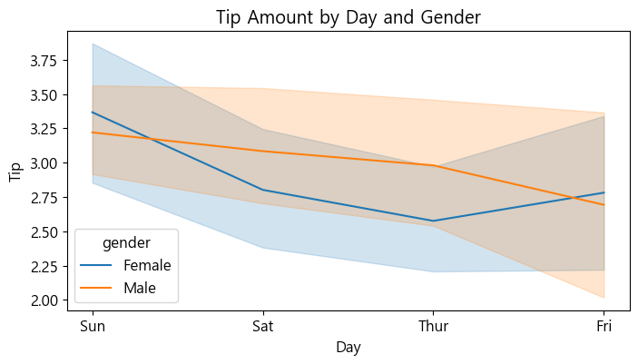

```python
# 다중 라인 플롯 그리기
# sns.lineplot(data=tips, x='day', y='tip', hue='gender', ci=None)
sns.lineplot(data=tips, x='day', y='tip', hue='gender')
# sns.lineplot(data=tips, x='day', y='tip', hue='gender')
plt.xlabel('Day')
plt.ylabel('Tip')
plt.title('Tip Amount by Day and Gender')
plt.show()
```

#### flights 데이터 활용

```python
flights = sns.load_dataset("flights")
flights.head()
```

|  | year | month | passengers |
| --- | --- | --- | --- |
| 0 | 1949 | Jan | 112 |
| 1 | 1949 | Feb | 118 |
| 2 | 1949 | Mar | 132 |
| 3 | 1949 | Apr | 129 |
| 4 | 1949 | May | 121 |

```python
flights.head()
```

|  | year | month | passengers |
| --- | --- | --- | --- |
| 0 | 1949 | Jan | 112 |
| 1 | 1949 | Feb | 118 |
| 2 | 1949 | Mar | 132 |
| 3 | 1949 | Apr | 129 |
| 4 | 1949 | May | 121 |

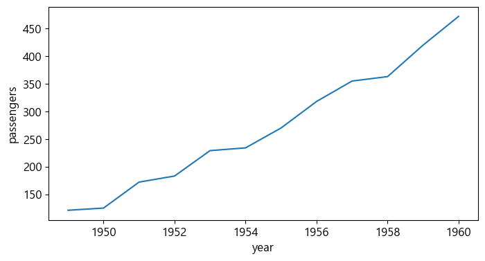

```python
may_flights = flights.query("month == 'May'")
sns.lineplot(data=may_flights, x="year", y="passengers")
```

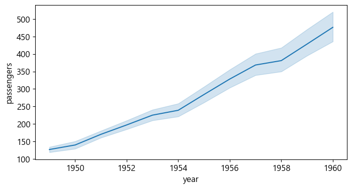

```python
sns.lineplot(data=flights, x="year", y="passengers")

plt.show()
```

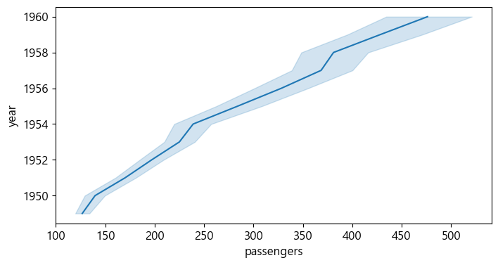

```python
sns.lineplot(data=flights, x="passengers", y="year", orient="y")

plt.show()
```

```python
flights_wide = flights.pivot(index="year", columns="month", values="passengers")
flights_wide.head()
```

| month year | Jan | Feb | Mar | Apr | May | Jun | Jul | Aug | Sep | Oct | Nov | Dec |
| --- | --- | --- | --- | --- | --- | --- | --- | --- | --- | --- | --- | --- |
| 1949 | 112 | 118 | 132 | 129 | 121 | 135 | 148 | 148 | 136 | 119 | 104 | 118 |
| 1950 | 115 | 126 | 141 | 135 | 125 | 149 | 170 | 170 | 158 | 133 | 114 | 140 |
| 1951 | 145 | 150 | 178 | 163 | 172 | 178 | 199 | 199 | 184 | 162 | 146 | 166 |
| 1952 | 171 | 180 | 193 | 181 | 183 | 218 | 230 | 242 | 209 | 191 | 172 | 194 |
| 1953 | 196 | 196 | 236 | 235 | 229 | 243 | 264 | 272 | 237 | 211 | 180 | 201 |

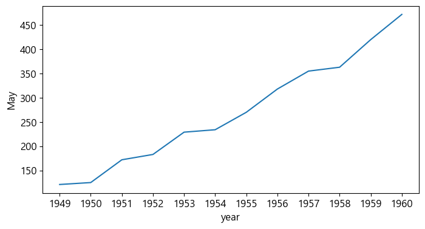

```python
sns.lineplot(data=flights_wide["May"])

plt.xticks(flights_wide.index)
plt.show()
```

```python
flights_wide.index
```

```
Index([1949, 1950, 1951, 1952, 1953, 1954, 1955, 1956, 1957, 1958, 1959, 1960], dtype='int64', name='year')
```

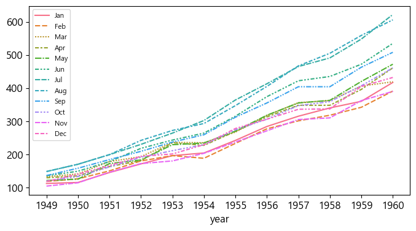

```python
# 년도별 월별 비행 횟수 확인
sns.lineplot(data=flights_wide)
# plt.legend(loc="best")
plt.legend(loc="best", prop={'size': 8})
plt.xticks(flights_wide.index)
plt.show()
```

```python
fmri = sns.load_dataset("fmri")
fmri.head()
```

|  | subject | timepoint | event | region | signal |
| --- | --- | --- | --- | --- | --- |
| 0 | s13 | 18 | stim | parietal | -0.017552 |
| 1 | s5 | 14 | stim | parietal | -0.080883 |
| 2 | s12 | 18 | stim | parietal | -0.081033 |
| 3 | s11 | 18 | stim | parietal | -0.046134 |
| 4 | s10 | 18 | stim | parietal | -0.037970 |

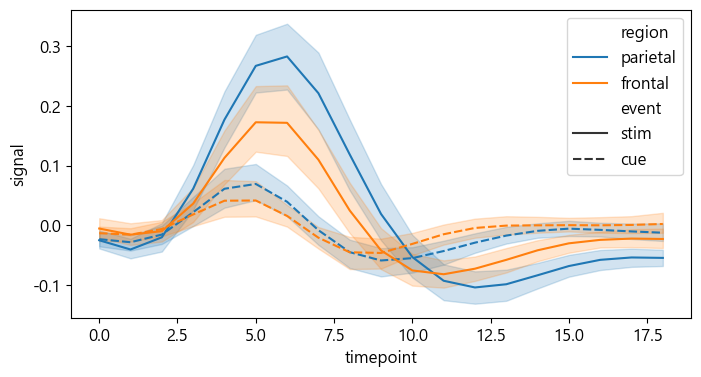

```python
sns.lineplot(data=fmri, x="timepoint", y="signal", hue="region", style="event")
```

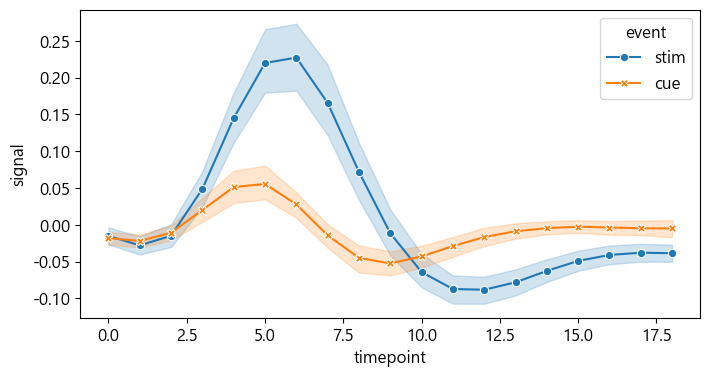

```python
sns.lineplot(
    data=fmri,
    x="timepoint", y="signal", hue="event", style="event",
    markers=True, dashes=False
)
```

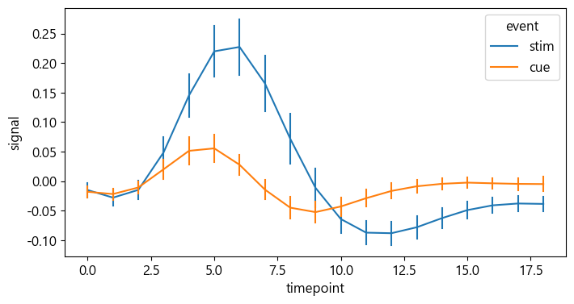

```python
# err_style="bars" : # 오차 막대 그래프 표시
# errorbar=("se", 2) :막대 그래프 계산할 때 표준오차로 계산하고, 크기는 2로 표시

sns.lineplot(
    data=fmri, x="timepoint", y="signal", hue="event",
    err_style="bars", errorbar=("se", 2),
)
```

## 5. Histogram

### 5-1. 기본 Histogram 그리기

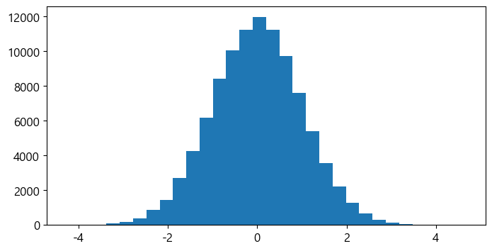

```python
N = 100000
bins = 30

x = np.random.randn(N)

plt.hist(x, bins=bins)

plt.show()
```

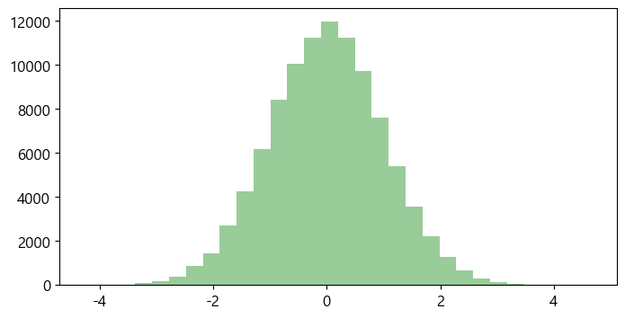

```python
sns.distplot(x, bins=bins, kde=False, hist=True, color='g')
```

`kde`을 **True**로 설정해주면, **Density**가 Y축에 표기 됩니다.

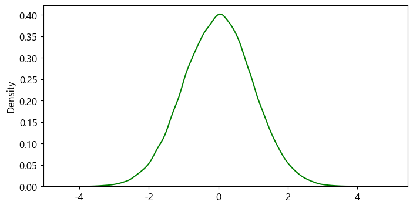

```python
sns.distplot(x, bins=bins, kde=True, hist=False, color='g')
```

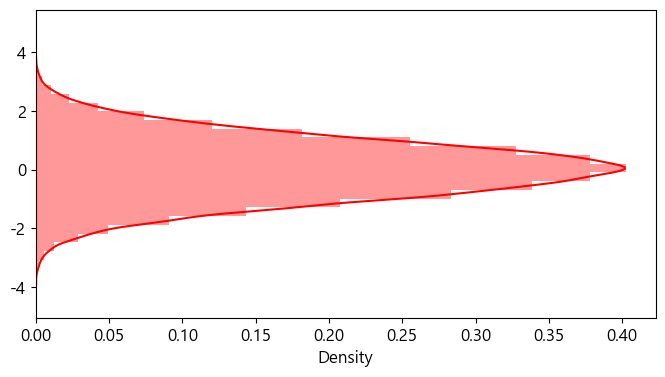

```python
sns.distplot(x, bins=bins, kde=True, hist=True, vertical=True, color='r')
```

- sharey: y축을 다중 그래프가 share
- tight_layout: graph의 패딩을 자동으로 조절해주어 fit한 graph를 생성

## 6. Pie Chart

**pie chart 옵션**

- explode: 파이에서 툭 튀어져 나온 비율
- autopct: 퍼센트 자동으로 표기
- shadow: 그림자 표시
- startangle: 파이를 그리기 시작할 각도

texts, autotexts 인자를 리턴 받습니다.

**texts**는 label에 대한 텍스트 효과를

**autotexts**는 파이 위에 그려지는 텍스트 효과를 다룰 때 활용합니다.

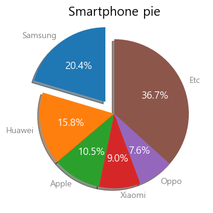

```python
labels = ['Samsung', 'Huawei', 'Apple', 'Xiaomi', 'Oppo', 'Etc']
sizes = [20.4, 15.8, 10.5, 9, 7.6, 36.7]
explode = (0.2, 0, 0, 0, 0, 0)

# texts, autotexts 인자를 활용하여 텍스트 스타일링을 적용합니다
patches, texts, autotexts = plt.pie(sizes,
                                    explode=explode,
                                    labels=labels,
                                    autopct='%1.1f%%',
                                    shadow=True,
                                    startangle=90)

plt.title('Smartphone pie', fontsize=15)

# label 텍스트에 대한 스타일 적용
for t in texts:
    t.set_fontsize(10)
    t.set_color('gray')

# pie 위의 텍스트에 대한 스타일 적용
for t in autotexts:
    t.set_color("white")
    t.set_fontsize(12)

plt.show()
```

Seaborn에서는 **pie plot을 지원하지 않습니다.**

## 7. Box Plot

샘플 데이터를 생성합니다.

```python
import matplotlib.pyplot as plt
import numpy as np
```

```python
# 샘플 데이터 생성
spread = np.random.rand(50) * 100
center = np.ones(25) * 50
flier_high = np.random.rand(10) * 100 + 100
flier_low = np.random.rand(10) * -100
data = np.concatenate((spread, center, flier_high, flier_low))
```

```python
data
```

```
array([ 43.68620118,  53.31784475,  48.13686559,  44.25708139,
        26.12818591,  52.36477423,  89.06934705,  10.62937376,
        99.79099961,  83.3493611 ,  78.04914475,  96.47029773,
        16.80546118,  58.35514152,  32.13620259,  41.94957949,
        15.98703888,  32.70522133,  59.04992784,  32.52609908,
        79.2181231 ,  69.89587997,  23.87651311,  30.65019205,
        48.71352201,  11.0549452 ,  82.09292996,  10.72391259,
        58.07088239,  11.61154309,  63.74133543,  29.42408249,
        25.52467322,  93.88619867,  69.6183543 ,  74.22943564,
        90.84798918,  23.25741885,  14.38109622,   2.13928519,
        20.25507137,  27.58492823,  83.24350133,  69.56565202,
        99.13210566,  78.35507885,  28.78051106,  23.20472656,
        88.84255855,  91.51670538,  50.        ,  50.        ,
        50.        ,  50.        ,  50.        ,  50.        ,
        50.        ,  50.        ,  50.        ,  50.        ,
        50.        ,  50.        ,  50.        ,  50.        ,
        50.        ,  50.        ,  50.        ,  50.        ,
        50.        ,  50.        ,  50.        ,  50.        ,
        50.        ,  50.        ,  50.        , 100.78493732,
       175.0626476 , 114.06338658, 158.42575852, 189.82399097,
       142.67746745, 144.48229501, 117.47867908, 123.32997053,
       190.37810875, -32.22180363, -60.28608083, -55.13699331,
       -61.89723383, -30.36791979, -27.43242679, -61.80825846,
       -11.08069528, -59.24036106, -43.18894846])
```

### 7-1 기본 박스플롯 생성

#### matplotlib로 boxplot 표현

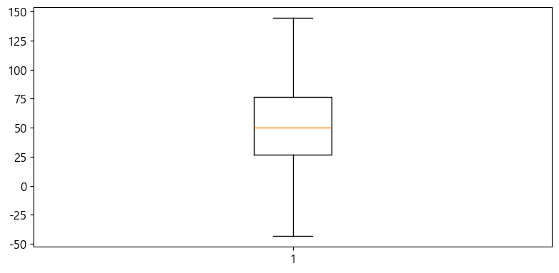

```python
plt.boxplot(data, showfliers=False)
plt.tight_layout()
plt.show()
```

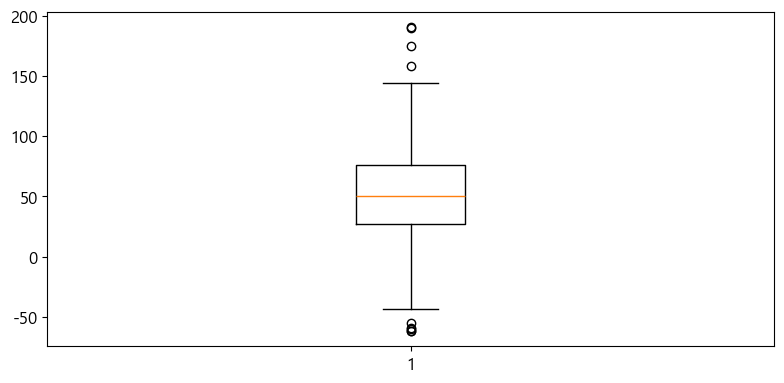

```python
plt.boxplot(data)
plt.tight_layout()
plt.show()
```

#### seaborn으로 boxplot 표현

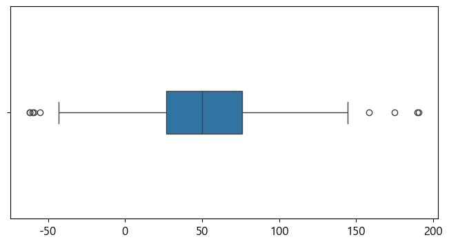

```python
# 수직방향
# sns.boxplot(data, orient='v', width=0.2)
# 수평방향
sns.boxplot(data, orient='h', width=0.2)
plt.show()
```

### 7-2. 다중 박스플롯 생성

seaborn에서 boxplot을 그릴 때는DataFrame을 가지고 그릴 때 주로 활용함

**barplot**과 마찬가지로, 용도에 따라 적절한 라이브러리를 사용합니다.

**실전 tip.**

- 그래프를 임의로 그려야 하는 경우 -> `matplotlib`
- DataFrame을 가지고 그리는 경우 -> `seaborn`

seaborn 에서는 `hue` 옵션으로 매우 쉽게 비교 **boxplot**을 그릴 수 있음

#### tips 데이터 활용

```python
import seaborn as sns
import pandas as pd

file_path = "datas/sns_tips.csv"
tips = pd.read_csv(file_path)
tips.head()
```

|  | total_bill | tip | gender | smoker | day | time | size |
| --- | --- | --- | --- | --- | --- | --- | --- |
| 0 | 16.99 | 1.01 | Female | No | Sun | Dinner | 2 |
| 1 | 10.34 | 1.66 | Male | No | Sun | Dinner | 3 |
| 2 | 21.01 | 3.50 | Male | No | Sun | Dinner | 3 |
| 3 | 23.68 | 3.31 | Male | No | Sun | Dinner | 2 |
| 4 | 24.59 | 3.61 | Female | No | Sun | Dinner | 4 |

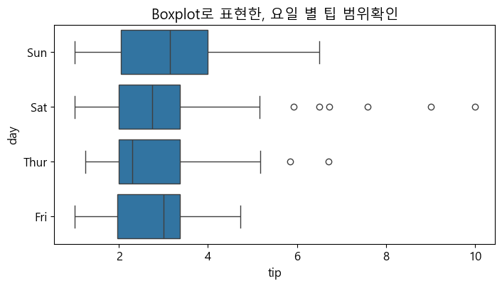

```python
plt.title("Boxplot로 표현한, 요일 별 팁 범위확인")
sns.boxplot(data=tips, x="tip", y="day")
plt.show()
```

x, y축 방향 바꾸기

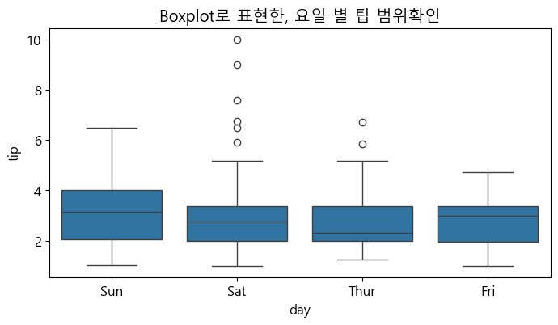

```python
plt.title("Boxplot로 표현한, 요일 별 팁 범위확인")
sns.boxplot(data=tips, x="day", y="tip")
plt.show()
```

이상치 표현 무사히기 whis=np.inf

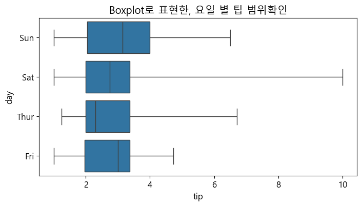

```python
plt.title("Boxplot로 표현한, 요일 별 팁 범위확인")
sns.boxplot(data=tips, x="tip", y="day", whis=np.inf)
plt.show()
```

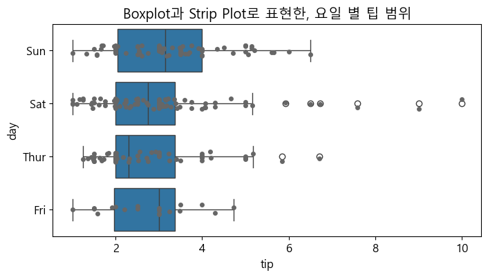

```python
plt.title("Boxplot과 Strip Plot로 표현한, 요일 별 팁 범위")
# sns.boxplot(data=tips, x="tip", y="day", whis=np.inf)
sns.boxplot(data=tips, x="tip", y="day")
sns.stripplot(data=tips, x="tip", y="day", jitter=True, color="0.4")
plt.show()
```

#### titanic 데이터 활용

```python
titanic = sns.load_dataset('titanic')
titanic.head()
```

|  | survived | pclass | sex | age | sibsp | parch | fare | embarked | class | who | adult_male | deck | embark_town | alive | alone |
| --- | --- | --- | --- | --- | --- | --- | --- | --- | --- | --- | --- | --- | --- | --- | --- |
| 0 | 0 | 3 | male | 22.0 | 1 | 0 | 7.2500 | S | Third | man | True | NaN | Southampton | no | False |
| 1 | 1 | 1 | female | 38.0 | 1 | 0 | 71.2833 | C | First | woman | False | C | Cherbourg | yes | False |
| 2 | 1 | 3 | female | 26.0 | 0 | 0 | 7.9250 | S | Third | woman | False | NaN | Southampton | yes | True |
| 3 | 1 | 1 | female | 35.0 | 1 | 0 | 53.1000 | S | First | woman | False | C | Southampton | yes | False |
| 4 | 0 | 3 | male | 35.0 | 0 | 0 | 8.0500 | S | Third | man | True | NaN | Southampton | no | True |

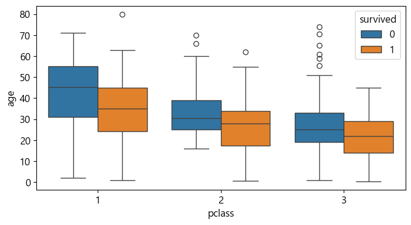

```python
sns.boxplot(data=titanic, x='pclass', y='age', hue='survived')
plt.show()
```

#### violinplot과 swarmplot으로 표현하기

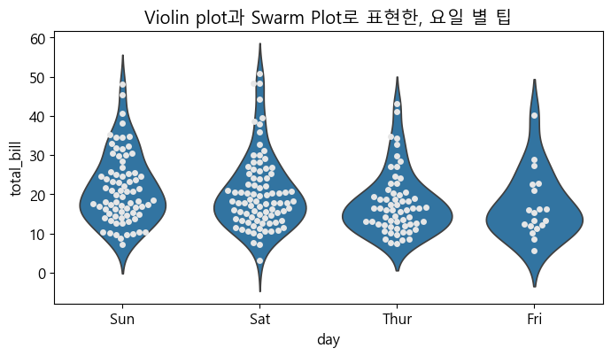

```python
plt.title("Violin plot과 Swarm Plot로 표현한, 요일 별 팁")
sns.violinplot(x="day", y="total_bill", data=tips, inner=None)
sns.swarmplot(x="day", y="total_bill", data=tips, color="0.9")
plt.show()
```

## 8. imshow

이미지(image) 데이터와 유사하게 행과 열을 가진 2차원의 데이터를 시각화 할 때는 `imshow`를 활용합니다.

```python
from sklearn.datasets import load_digits

digits = load_digits()
X = digits.images[:10]
X[0]
```

```
array([[ 0.,  0.,  5., 13.,  9.,  1.,  0.,  0.],
       [ 0.,  0., 13., 15., 10., 15.,  5.,  0.],
       [ 0.,  3., 15.,  2.,  0., 11.,  8.,  0.],
       [ 0.,  4., 12.,  0.,  0.,  8.,  8.,  0.],
       [ 0.,  5.,  8.,  0.,  0.,  9.,  8.,  0.],
       [ 0.,  4., 11.,  0.,  1., 12.,  7.,  0.],
       [ 0.,  2., 14.,  5., 10., 12.,  0.,  0.],
       [ 0.,  0.,  6., 13., 10.,  0.,  0.,  0.]])
```

- `load_digits`는 0~16 값을 가지는 array로 이루어져 있습니다.
- 1개의 array는 8 X 8 배열 안에 표현되어 있습니다.
- 숫자는 0~9까지 이루어져있습니다.

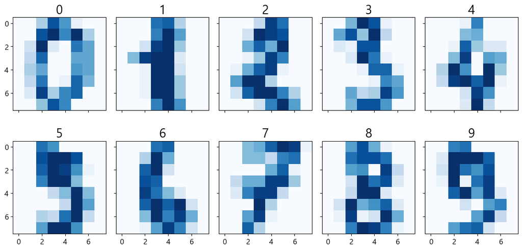

```python
fig, axes = plt.subplots(nrows=2, ncols=5, sharex=True, figsize=(12, 6), sharey=True)

for i in range(10):
    axes[i//5][i%5].imshow(X[i], cmap='Blues')
    axes[i//5][i%5].set_title(str(i), fontsize=20)

plt.tight_layout()
plt.show()
```